# 第A13章 曲げ応力

## A13.0 はじめに

図aの棒ABは、軸圧縮荷重 $P$ を受けている。圧縮応力によって棒に座屈が生じない場合、棒が圧縮応力下で縮むにつれて、1-1や2-2のような棒の断面は互いに平行に移動する。

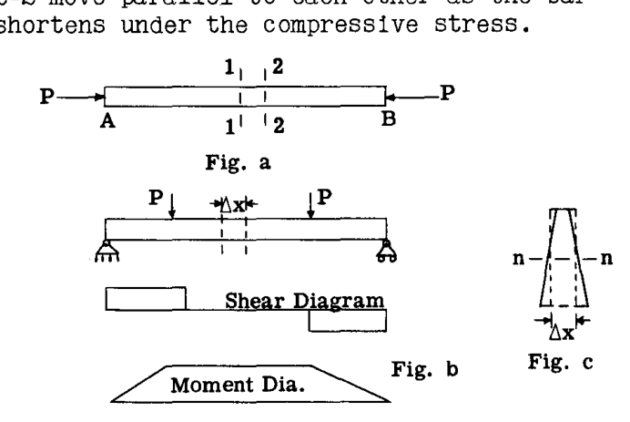

図a, 図b, 図c

図bでは、同じ棒が2つの荷重 $P$ を受ける単純支持梁として使用されている様子が示されている。この梁の荷重に対する剪断力図および曲げモーメント図も示されている。断面1-1と2-2の間の梁の部分は、この領域で剪断力がゼロであるため、純粋曲げを受ける。

純粋曲げを受けるこの梁の領域から切り取った梁要素 $\Delta x$ についての実験的証拠は、曲げの後も平面断面は平面のままであるが、図cに示すように、平面断面が互いに回転することを示している。ここで、破線は応力を受けていない梁要素を表し、太線は純粋曲げが生じた後の形状を表している。したがって、上部の繊維は縮んで圧縮応力を受け、下部の繊維は伸びて引張応力を受ける。したがって、断面上の特定の平面 n-n では、繊維は変形を起こさず、応力はゼロになる。この純粋曲げにおいて応力がゼロになる位置を「中立軸」と呼ぶ。

## A13.1 中立軸の位置

図dは、自由端に純粋なモーメントを受ける片持ち梁を示しており、この作用モーメントの下で、梁は図のように誇張されたたわみ形状をとる。

作用する曲げモーメントベクトルは $Z$ 軸に平行に作用する。換言すれば、作用する曲げモーメントは $Z$ 軸に垂直な平面内で作用する。長さ $L$ の梁要素を考える。図dは、梁の曲げの後に平面断面が平面のまま維持されるときの、この要素のひずみを示している。

梁の断面は均質、すなわち同一の材料でできており、梁の応力は材料の比例限度以下である、すなわちフックの法則が成り立つと仮定する。

相似三角形の幾何学的関係から、

$$\frac{e}{y} = \frac{e_c}{c} \quad \text{または} \quad e = \frac{y}{c} e_c$$
(A)

ヤング率 $E$ より、次式が得られる。

$$E = \frac{\text{単位応力}}{\text{単位ひずみ}} = \frac{-\sigma_y}{e/L}$$

ここで、 $\sigma_y$ は変形 $e$ における曲げ応力であり、圧縮であるためマイナスの符号が与えられる。

$\sigma_y$ について解くと、

$$\sigma_y = -E \frac{e_c}{c} \frac{y}{L}$$

最も外側の繊維は距離 $y = c$ にある。したがって、

$$\sigma_c = -E \frac{e_c}{L}$$

これより、

$$\sigma_y = -\frac{\sigma_c}{c} y$$
(B)

梁断面に垂直な、すなわち $X$ 方向の曲げ応力の釣り合いから、 $\Sigma F_x = 0$ 、すなわち以下のように書くことができる。

$$\Sigma F_x = -\frac{\sigma_c}{c} \int y dA = 0$$

しかし、この式において $\frac{\sigma_c}{c}$ の項はゼロではないため、 $\int y dA$ の項がゼロでなければならず、これが真となるのは中立軸が梁断面の図心軸と一致する場合のみである。

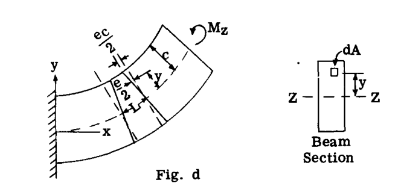

図d

梁が非均質である場合、すなわち弾性係数が梁断面全体で一定ではない場合、またフックの法則が適用されない場合や応力-ひずみ関係が非線形である場合には、中立軸は梁断面の図心を通らない。これらの梁の条件については、本章の後半で説明する。

## A13.2 比例限度以下の応力を受ける均質梁の曲げ応力公式

以下の誘導では、外荷重の平面が梁のたわみ軸（剪断中心軸）を含んでいるため、梁はねじり力を受けないと仮定する。ねじり力が存在する場合、支持点などで生じる梁断面の自由な反りが拘束されると、曲げ応力が発生する。たわみ軸およびねじり効果の問題については、以降の章で取り上げる。

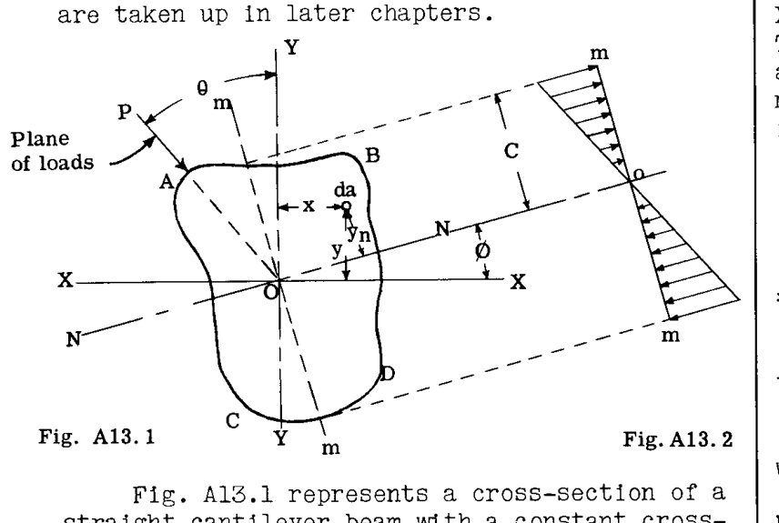

図 A13.1, 図 A13.2

図A13.1は、図心 $O$ を通る $Y-Y$ 軸と角度 $\theta$ をなす平面内にある外荷重を受ける、一定断面の直線片持ち梁の断面を示している。図を簡単にするために、たわみ軸は図心軸と一致すると仮定しているが、これは一般には正しくない。

$NN$ を与えられた荷重下での中立軸とし、 $\phi$ を中立軸と $X-X$ 軸の間の角度とする。問題は、中立軸の方向と、断面上の任意の点における曲げ応力 $\sigma$ を求めることである。

基礎的な梁理論では、材料の比例限度内において、単位応力は中立軸からの距離に正比例して変化すると仮定される。したがって、図A13.2は、中立軸 $N-N$ に垂直な線 $mm$ に沿って応力がどのように変化するかを示している。

中立軸から距離 $y_n$ の位置にある任意の点における単位曲げ応力を $\sigma$ とする。このとき、 $dA$ 上の応力 $\sigma$ は次式のようになる。

$$\sigma = k y_n$$
(1)

ここで $k$ は定数である。中立軸の位置は未知であるため、便宜上、 $y_n$ を $X-X$ および $Y-Y$ 軸に関する直交座標で表す。

したがって、

$$y_n = (y - x \tan \phi) \cos \phi$$

$$= y \cos \phi - x \sin \phi$$
(2)

すると、式(1)は次のようになる。

$$\sigma = k (y \cos \phi - x \sin \phi)$$
(3)

この式には、 $\sigma$ 、 $k$ 、 $\phi$ の3つの未知数が含まれている。解を得るために、釣り合い条件からさらに2つの式が提供される。すなわち、断面 $ABCD$ の片側にある外力の $X-X$ および $Y-Y$ 直交軸まわりのモーメントの和は、それぞれ同じ軸まわりの断面の内部応力のモーメントの和と等しく、かつ逆向きでなければならない。

$M$ を荷重の平面における曲げモーメントとする。このとき、 $X-X$ および $Y-Y$ 軸まわりのモーメントは、それぞれ $M_x = M \cos \theta$ および $M_y = M \sin \theta$ である。梁断面上の応力の $X-X$ 軸まわりのモーメントは $\int \sigma dA y$ である。したがって、 $X-X$ 軸まわりのモーメントをとると、釣り合い条件から次式が得られる。

$$M \cos \theta = \int \sigma dA y$$

$$= \int k (\cos \phi y^2 dA - \sin \phi xy dA)$$

$$= k \cos \phi \int y^2 dA - k \sin \phi \int xy dA$$
(4)

同様に、 $Y-Y$ 軸まわりのモーメントをとると、

$$M \sin \theta = \int \sigma dA x$$

これより、

$$M \sin \theta = -k \sin \phi \int x^2 dA + k \cos \phi \int xy dA$$
(4a)

## A13.3 方法1. 主軸まわりのモーメントに対する応力

式(4)において、 $\int y^2 dA$ という項は $X-X$ 軸まわりの断面積の慣性モーメントであり、これを $I_x$ と表す。また、 $\int xy dA$ という項は $X-X$ および $Y-Y$ 軸まわりの相乗モーメントを表す。しかし、主軸に関する相乗モーメントはゼロであることを我々は知っている。したがって、もし $XX$ と $YY$ が主軸と一致するように選択すれば、式(4)は次のように書くことができる。

$$M \cos \theta = k \cos \phi I_{x_p}$$
(5)

同様に、式(4a)から、

$$M \sin \theta = -k \sin \phi I_{y_p}$$
(6)

断面上の任意の点における単位応力 $\sigma$ を求めるために、式(5)を $\cos \phi$ について、式(6)を $\sin \phi$ について解き、これらの値を(3)に代入すると、曲げ応力を表すサブスクリプト $b$ を付与した以下の式が得られる。

$$\sigma_b = -\frac{M \cos \theta y_p}{I_{x_p}} - \frac{M \sin \theta x_p}{I_{y_p}}$$

主軸まわりの分解された曲げモーメント $M \cos \theta$ および $M \sin \theta$ にそれぞれ記号 $M_{x_p}$ および $M_{y_p}$ を与える。このとき、次のように書くことができる。

$$\sigma_b = -\frac{M_{x_p} y_p}{I_{x_p}} - \frac{M_{y_p} x_p}{I_{y_p}}$$
(7)

各項の前にマイナス符号が置かれているのは、正の曲げモーメントがあるときに $\sigma_b$ に負の値（圧縮）を与えるためである。ここで、 $M_{x_p}$ は $x_p-x_p$ 軸まわりの偶力のモーメントであり、第1象限（右上）に圧縮を生じるときに正となる。 $M_{y_p}$ は $y_p-y_p$ 軸まわりのモーメントであり、これも第1象限に圧縮を生じるときに正となる。

### 対称梁断面の曲げ応力式

対称軸は主軸であるため（項 $\int xy dA = 0$ ）、対称な $XX$ および $YY$ 軸まわりの曲げに対する曲げ応力式は、明らかに次のようになる。

$$\sigma_b = -\frac{M_x y}{I_x} - \frac{M_y x}{I_y}$$
(7a)

## A13.4 方法2. 与えられた荷重平面に対する中立軸の使用による応力

$XX_p$ 主軸から測定した中立軸 $NN$ の方向は、式(6)を(5)で割ることによって得られる。

$$\tan \alpha = -\frac{I_{x_p} \tan \theta}{I_{y_p}}$$
(8)

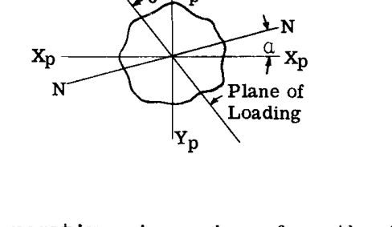

中立軸の角度

負の符号は、 $\theta$ が一方の主軸から測定され、 $\phi$ が他方の主軸から同じ方向に測定されるという事実から生じる。

式(8)は特定の荷重平面に対する中立軸の位置を与えるため、任意の点における応力は、外力モーメントを中立軸 $N-N$ に垂直な平面内に分解し、中立軸まわりの慣性モーメントを使用することによって求めることができる。したがって、

$$\sigma_b = -\frac{[M \cos (\theta - \alpha)] y_n}{I_n} = -\frac{M_n y_n}{I_n}$$
(9)

$I_n$ は、第A3章で示された関係式、すなわち以下から決定できる。

$$I_n = I_{x_p} \cos^2 \alpha + I_{y_p} \sin^2 \alpha$$
(10)

## A13.5 方法3. 断面の図心を通る任意の直交軸のペアを基準としたモーメント、断面特性、および距離からの応力

繊維応力は、主軸や中立軸に頼ることなく求めることができる。

式(4)は次のように書くことができる。

$$M_x = k \cos \phi I_x - k \sin \phi I_{xy}$$
(11)

ここで、 $I_x = \int y^2 dA$ 、 $I_{xy} = \int xy dA$ 、および $M_x = M \cos \theta$ である。

同様に、

$$M_y = -k \sin \phi I_y + k \cos \phi I_{xy}$$
(12)

式(11)と(12)を $\sin \phi$ と $\cos \phi$ について解き、それらの値を式(3)に代入すると、繊維応力 $\sigma_b$ について以下の式が得られる。

$$\sigma_b = -\frac{(M_y I_x - M_x I_{xy})}{I_x I_y - I_{xy}^2} x - \frac{(M_x I_y - M_y I_{xy})}{I_x I_y - I_{xy}^2} y$$
(13)

簡略化のために、以下のように置く。

$$K_1 = \frac{I_{xy}}{I_x I_y - I_{xy}^2}$$

$$K_2 = \frac{I_y}{I_x I_y - I_{xy}^2}$$

$$K_3 = \frac{I_x}{I_x I_y - I_{xy}^2}$$

これらの値を式(13)に代入する。

$$\sigma_b = -(K_3 M_y - K_1 M_x) x - (K_2 M_x - K_1 M_y) y$$
(14)

方法2では、与えられた荷重平面に対する中立軸の位置を見つけるために式(8)が使用された。中立軸の位置は、任意の直交図心軸 $X$ および $Y$ に対しても以下のように見つけることができる。

中立軸上の任意の点における応力はゼロでなければならないため、式(14)から次のように書くことができる。

$$(K_3 M_y - K_1 M_x) x = -(K_2 M_x - K_1 M_y) y$$

これは中立軸上にあるすべての点について成り立つ。図A13.1から $\tan \phi = \frac{y}{x}$ である。

したがって、

$$\tan \phi = -\frac{(K_3 M_y - K_1 M_x)}{(K_2 M_x - K_1 M_y)}$$
(15)

## A13.6 3つの方法の長所と短所

方法2（与えられた荷重平面に対する中立軸まわりの曲げ）は、梁全体の曲げに対する真の挙動を最もよく視覚的に表している。最大繊維応力の点は、中立軸に垂直に定規を置き、それを中立軸に沿って動かして、中立軸から最も遠い梁断面上の点を見つけることによって容易に決定される。航空機の設計では、荷重平面の方向を変化させる多くの設計条件があるため、各梁断面に対していくつかの中立軸を計算しなければならず、これは他の2つの方法と比較して不利な点である。

航空機構造物の剪断力とモーメントを決定する際、空気力と着陸力を航空機の $XYZ$ 軸に平行に分解することが一般的であり、これらの結果は方法3で直接使用できるが、方法1では主軸に関してさらに分解する必要がある。方法1と3は、方法2よりも広く使用されている。

1つの主軸まわりの曲げモーメントは他方の主軸まわりの曲げを生じさせないため、内部の剪断流分布を計算する際には主軸を使用すると便利である。

## A13.7 たわみ

たわみは、与えられた荷重平面に対する中立軸まわりの梁の断面特性を使用し、中立軸に垂直な平面内に分解された曲げモーメントを使用して求めることができる。また、曲げモーメントを2つの主平面に分解し、主軸まわりの特性を使用することによってもたわみを求めることができる。結果としてのたわみは、主平面方向のたわみのベクトル和である。

## A13.8 例題

### 例題1

図A13.3は、4つのコーナーフランジ部材 $a$ , $b$ , $c$ , $d$ を持つ非対称な1セルボックス梁を示している。断面 $abcd$ から 50インチ 離れた位置に作用する荷重 $P_x$ および $P_y$ による、4つのコーナー部材の曲げ軸応力を求めることが要求されている。

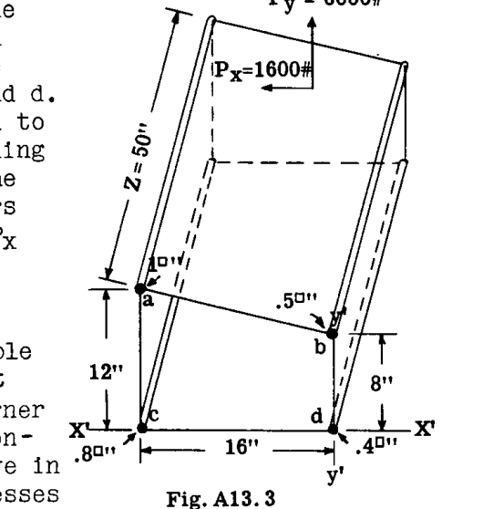

図 A13.3

この例題の解決において、コーナー部材をつなぐ板は曲げに対して無効であるとみなす。応力は、本章で紹介した3つの方法のそれぞれによって決定される。

### 解法

3つの方法すべてに共通する最初のステップは、図心 $X$ および $Y$ 軸まわりの慣性モーメントの計算である。表A13.1に詳細な計算を示す。特性はまず基準軸 $x'x'$ および $y'y'$ まわりで計算され、その後、平行移動によって平行図心軸に転送される。

#### 表 A13.1

| 部材 | 面積 “A” | $y'$ | $x'$ | $Ay'$ | $Ax'$ | $Ay'^2$ | $Ax'^2$ | $Ax'y'$ |
| --- | --- | --- | --- | --- | --- | --- | --- | --- |
| a | 1.0 | 12 | -16 | 12 | -16 | 144.0 | 256.0 | -192 |
| b | 0.5 | 8 | 0 | 4 | 00 | 32.0 | 0 | 0 |
| c | 0.8 | 0 | -16 | 0 | -12.8 | 0 | 204.8 | 0 |
| d | 0.4 | 0 | 0 | 0 | 0 | 0 | 0 | 0 |
| **合計** | **2.7** |  |  | **16** | **-28.8** | **176.0** | **460.8** | **-192** |

断面の図心の計算：

$$\bar{x} = \frac{\Sigma Ax'}{\Sigma A} = \frac{-28.8}{2.7} = -10.667\text{インチ}$$

$$\bar{y} = \frac{\Sigma Ay'}{\Sigma A} = \frac{16}{2.7} = 5.926\text{インチ}$$

$$I_x = 176 - 2.7 \times 5.926^2 = 81.18$$

$$I_y = 460.8 - 2.7 \times 10.667^2 = 153.58$$

$$I_{xy} = -192 - (2.7 \times -10.667 \times 5.926) = -21.33$$

### 方法1による解法（主軸まわりの曲げ）

$x$ 軸と主軸の間の角度 $\phi$ は、次の式によって与えられる。

$$\tan 2\phi = \frac{2 I_{xy}}{I_y - I_x} = \frac{2(-21.33)}{153.58 - 81.18} = \frac{-42.66}{72.40} = -0.589$$

$$2\phi = 30^\circ - 30', \quad \phi = -15^\circ = 15'$$

$$I_{x_p} = I_x \cos^2 \phi + I_y \sin^2 \phi - 2 I_{xy} \sin \phi \cos \phi$$

$$= 81.18 \times .9648^2 + 153.58 \times .2636^2 - (-21.33 \times .2636 \times .9648) \times 2$$

$$= 75.56 + 10.67 - 10.85 = 75.38 \text{ in}^4$$

$$I_{y_p} = I_x \sin^2 \phi + I_y \cos^2 \phi + 2 I_{xy} \sin \phi \cos \phi$$

$$= 81.18 \times .2636^2 + 153.58 \times .9648^2 + 10.85 = 159.34 \text{ in}^4$$

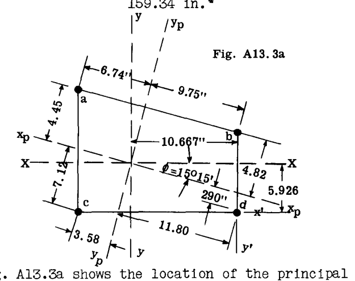

図 A13.3a

図A13.3aは、主軸の位置、および各コーナー部材から各主軸までの垂直距離を示している。これらの距離は、初等幾何学から容易に決定される。

$X$ および $Y$ 軸まわりの外力曲げモーメントは、

$$M_x = 6000 \times 50 = 300,000\text{ポンド・インチ}$$

$$M_y = -1600 \times 50 = -80,000\text{ポンド・インチ}$$

これらのモーメントを $x_p$ および $y_p$ 主軸まわりの曲げモーメントに分解する。

$$M_{x_p} = 300,000 \times \cos 15^\circ 15' - 80,000 \times \sin 15^\circ 15'$$

$$= 289,700 - 21,000 = 268,700\text{ポンド・インチ}$$

$$M_{y_p} = -300,000 \times \sin 15^\circ 15' - 80,000 \times \cos 15^\circ 15'$$

$$= -79,000 - 77,200 = -156,200\text{ポンド・インチ}$$

（正のモーメントは第1象限に圧縮を生じさせる）。

応力の計算：

$$\sigma_b = -\frac{M_{x_p} y_p}{I_{x_p}} - \frac{M_{y_p} x_p}{I_{y_p}}$$

#### ストリンガー a

$$_p = -6.74, \quad y_p = 4.45$$

したがって、

$$\sigma_b = -\frac{268,700 \times 4.45}{75.38} - \frac{-156,200 \times (-6.74)}{159.34}$$

$$= -15,900 - 6600 = -22,500 \text{ポンド/平方インチ}$$

#### ストリンガー b

$$_p = 9.75, \quad y_p = 4.82$$

$$\sigma_b = -\frac{268,700 \times 4.82}{75.38} - \frac{-156,200 \times 9.75}{159.34}$$

$$= -17,180 + 9570 = -7610 \text{ポンド/平方インチ}$$

#### ストリンガー c

$$_p = -3.58, \quad y_p = -7.12$$

$$\sigma_b = -\frac{268,700 \times (-7.12)}{75.38} - \frac{-156,200 \times (-3.58)}{159.34}$$

$$= 25,400 - 3520 = 21,880\text{ポンド/平方インチ}$$

同様に、ストリンガー d について、 $\sigma_b = 21,900$ ポンド/平方インチ。

### 方法2による解法（中立軸法）

$\theta'$ を $yy$ 軸と荷重平面の間の角度とする。

$$\tan \theta' = -\frac{80,000}{300,000} = -0.2667$$

したがって、

$$\theta' = 14^\circ 56' \quad \text{および} \quad \theta = 14^\circ 56' + 15^\circ 15' = 30^\circ 11'$$

$\alpha$ を中立軸 $NN$ と $X_p$ 軸の間の角度とする。

$$\tan \alpha = -\frac{I_{x_p} \tan \theta}{I_{y_p}} = -\frac{75.38 \times (-0.5816)}{159.34} = 0.275$$

したがって、 $\alpha = 15^\circ 24'$ （図A13.3bを参照）。

$X$ 軸と中立軸の間の角度はわずか $9'$ であるため、次のように言うことができる。

$$I_N = I_x = 81.18$$

外力曲げモーメントを中立軸に垂直に分解すると、次式が得られる。

$$M_N = 300,000 \times .9999 + 80,000 \times \sin 0^\circ 9' = 300,200\text{ポンド・インチ}$$

任意の点における曲げ応力は、次式で与えられる。

$$\sigma_b = -\frac{M_N y_n}{I_N}$$

#### ストリンガー a

$$y_n = 6.074 + 5.33 \times .0025 = 6.087\text{インチ}$$

$$\sigma_b = -\frac{300,200 \times 6.087}{81.18} = -22,500\text{ポンド/平方インチ}$$

#### ストリンガー b

$$y_n = 2.055\text{インチ}$$

$$\sigma_b = -\frac{300,200 \times 2.05}{81.18} = -7570\text{ポンド/平方インチ}$$

#### ストリンガー c

$$y_n = -5.92\text{インチ}$$

$$\sigma_b = -\frac{300,200 \times (-5.92)}{81.18} = 21,850\text{ポンド/平方インチ}$$

#### ストリンガー d

$$y = -5.95\text{インチ}$$

$$\sigma_b = -\frac{300,200 \times (-5.95)}{81.18} = 22,000\text{ポンド/平方インチ}$$

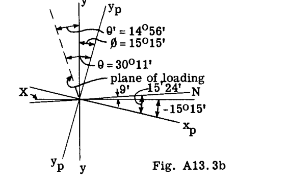

図 A13.3b

### 方法3による解法（X軸およびY軸まわりの特性を使用する方法）

$$M_x = 300,000, \quad M_y = -80,000$$

$$I_x = 81.18, \quad I_y = 153.58, \quad I_{xy} = -21.33$$

$$K_1 = \frac{I_{xy}}{I_x I_y - I_{xy}^2} = \frac{-21.33}{81.18 \times 153.58 - 21.33^2} = \frac{-21.33}{12,016} = -0.00177$$

$$K_2 = \frac{I_y}{I_x I_y - I_{xy}^2} = \frac{153.58}{12,016} = 0.012794$$

$$K_3 = \frac{I_x}{I_x I_y - I_{xy}^2} = \frac{81.18}{12,016} = 0.00674$$

$$\sigma_b = -(K_3 M_y - K_1 M_x) x - (K_2 M_x - K_1 M_y) y$$

#### ストリンガー a

$$x = -5.333\text{インチ}, \quad y = 6.074\text{インチ}$$

$$\sigma_b = -[0.00674 \times (-80,000) + 0.00177 \times 300,000] x - [0.012794 \times 300,000 - 0.00177 \times (-80,000)] y$$

したがって、

$$\sigma_b = (8) x - (3697) y$$

$$\sigma_b = 8 \times (-5.33) - 3697 \times 6.074 = -22,450\text{ポンド/平方インチ}$$

#### ストリンガー b

$$x = 10.667, \quad y = 2.074$$

$$\sigma_b = 8 \times 10.667 - 3697 \times 2.074 = 85 - 7660 = -7575\text{ポンド/平方インチ}$$

#### ストリンガー c

$$x = -5.333, \quad y = -5.926$$

$$\sigma_b = 8 \times (-5.333) - 3697 \times (-5.926) = -42 + 21,900 = 21,862\text{ポンド/平方インチ}$$

#### ストリンガー d

$$x = 10.667, \quad y = -5.926$$

$$\sigma_b = 8 \times 10.667 - 3697 \times (-5.926) = 85 + 21,900 = 21,985\text{ポンド/平方インチ}$$

**注**: 3つの方法による応力 $\sigma_b$ は10インチ計算尺で計算されたため、3つの方法の結果の間にはわずかな不一致がある。

### 荷重 Mx および My による X および Y 図心軸まわりの曲げの仮定による応力の誤差

$$\sigma_b = -\frac{M_x y}{I_x} - \frac{M_y x}{I_y} \quad (\text{式 7a})$$

#### ストリンガー a

$$y = 6.074, \quad x = -5.33$$

$$\sigma_b = -\frac{300,000 \times 6.074}{81.18} - \frac{-80,000 \times (-5.33)}{153.58} = -25,190\text{ポンド/平方インチ}$$

#### ストリンガー b

$$y = 2.07, \quad x = 10.667$$

$$\sigma_b = -\frac{300,000 \times 2.07}{81.18} - \frac{-80,000 \times 10.667}{153.58} = -2110\text{ポンド/平方インチ}$$

同様に、ストリンガー c および d について、 $\sigma_b = 19,130$ および $\sigma_b = 27,440$ となる。

これらの結果を前の結果と比較すると、かなりの誤差が存在することがわかる。これらの誤った応力の下では、内部抵抗モーメントは $X$ および $Y$ 軸まわりの外力曲げモーメントと等しくならない。

### 例題2

図A13.4は、片持ち2セル応力外板翼ボックス梁の一部を示している。この例では、梁の断面は一定であると考えられ、その断面は第A3章の図A3.13で使用されたものと同一であり、断面特性は計算済みで以下の通りである。

$$\theta = 8^\circ - 16.25', \quad I_{x_p} = 181.2, \quad I_{y_p} = 437$$

断面ABC（図A13.4）より外側の翼上の合空気力は、 $Y$ 方向に上向きに作用する $14,260$ ポンド、および $X$ 方向に前向きに作用する $760$ ポンドであり、これらの合荷重の位置は断面ABCから50インチである。

図心またはストリンガー番号(1)、(9)、(12)における曲げ応力強度を、3つの方法すべてを用いて計算する。

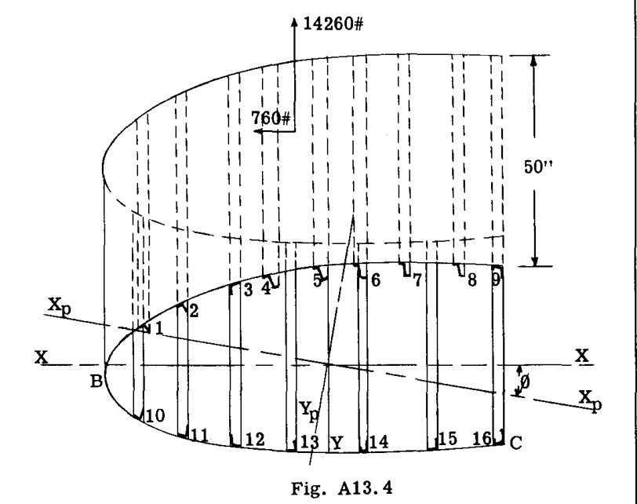

図 A13.4

### 方法1による解法（主軸まわりの曲げ）

断面ABCにおける $X$ および $Y$ 軸まわりの曲げモーメントは、

$$M_x = 14,260 \times 50 = 713,000\text{ポンド・インチ}$$

$$M_y = -760 \times 50 = -38,000\text{ポンド・インチ}$$

これらのモーメントは、次のように主軸まわりの曲げモーメントに分解される。

$$M_{x_p} = 713,000 \times \cos \theta - 38,000 \times \sin \theta = 700,000\text{ポンド・インチ}$$

$$M_{y_p} = -713,000 \times \sin \theta - 38,000 \times \cos \theta = -140,000\text{ポンド・インチ}$$

式(7)から、 $\sigma_b$ の一般公式は次のようになる。

$$\sigma_b = -\frac{M_{x_p} y_p}{I_{x_p}} - \frac{M_{y_p} x_p}{I_{y_p}}$$

#### ストリンガー 1 の応力：

$$y_p = 1.85\text{インチ} \quad \text{および} \quad x_p = -17.86\text{インチ}$$

$$\sigma_b = -\frac{(700,000 \times 1.85)}{181.17} - \frac{-140,000 \times (-17.86)}{437}$$

$$= -7150 - 5700 = -12,850\text{ポンド/平方インチ}$$

#### ストリンガー 9 の応力：

$$y_p = 9.04\text{インチ}, \quad x_p = 14.24\text{インチ}$$

$$\sigma_b = -\frac{(700,000 \times 9.04)}{181.17} - \frac{-140,000 \times 14.24}{437}$$

$$= -34,900 + 4560 = -30,340\text{ポンド/平方インチ}$$

#### ストリンガー 12 の応力：

$$y_p = -6.80\text{インチ}, \quad x_p = -8.22\text{インチ}$$

### 方法2による解法（中立軸法）

図A13.5において、 $\theta'$ を $Y-Y$ 軸と合曲げモーメントの平面との間の角度とする。合曲げモーメントは、

$$\tan \theta' = -\frac{38,000}{713,000} = -0.0533, \quad \theta' = -3^\circ 3'$$

$\theta$ を合モーメントの平面と $Y_p$ 軸との間の角度とする。

式(8)から、 $X_p$ 軸と中立軸の間の角度は $\alpha$ であり、

$$\tan \alpha = -\frac{I_{x_p} \tan \theta}{I_{y_p}} = -\frac{181.17 \times (-0.200)}{437} = 0.083$$

したがって、 $\alpha = 4^\circ 45'$ 。

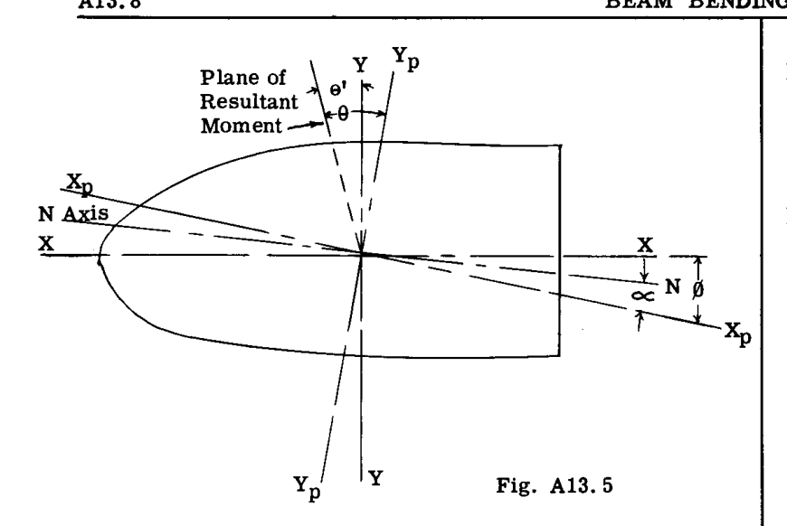

図 A13.5

図A13.5は、中立軸、主軸、および荷重平面の相対的な位置を示している。

中立軸 $N$ まわりの外力合モーメントの成分は次のようになる。

$$M_N = 714,060 \times \sin 83^\circ 26' = 709,350\text{ポンド・インチ}$$

$$I_N = I_{x_p} \cos^2 \alpha + I_{y_p} \sin^2 \alpha$$

$$= 181.17 \times .9966^2 + 437 \times .0878^2 = 183.37\text{インチ}^4$$

#### ストリンガー 1 の応力：

$$y_{n_1} = (y_p + x_p \tan \alpha) \cos \alpha = (1.85 + 17.86 \times .083) \times .9966 = 3.32\text{インチ}$$

$$\sigma_{b_1} = -\frac{M_N y_n}{I_N} = -\frac{709,350 \times 3.32}{183.37} = -12,850\text{ポンド/平方インチ}$$

#### ストリンガー 9 の応力：

$$y_{n_9} = (9.04 - 14.24 \times .083) \times .9966 = 7.84\text{インチ}$$

$$\sigma_{b_9} = -\frac{709,350 \times 7.84}{183.37} = -30,300\text{ポンド/平方インチ}$$

#### ストリンガー 12 の応力：

$$\sigma_{b_{12}} = -\frac{709,350 \times 6.10}{183.37} = 23,600\text{ポンド/平方インチ}$$

### 方法3による解法

$$M_x = 713,000\text{ポンド・インチ}, \quad M_y = -38,000\text{ポンド・インチ}$$

$$I_x = 186.46, \quad I_y = 431.7, \quad I_{xy} = -36.41$$

定数 $K_1$ 、 $K_2$ 、および $K_3$ をまず決定する。

$$K_1 = \frac{I_{xy}}{I_x I_y - I_{xy}^2} = \frac{-36.41}{186.46 \times 431.7 - 36.41^2} = -0.00046$$

$$K_2 = \frac{I_y}{I_x I_y - I_{xy}^2} = \frac{431.7}{186.46 \times 431.7 - 36.41^2} = 0.00545$$

#### ストリンガー 1 の応力：

$$y_1 = 4.39\text{インチ}, \quad x_1 = -17.41\text{インチ}$$

$$\sigma_b = -(K_3 M_y - K_1 M_x) x - (K_2 M_x - K_1 M_y) y$$

$$\sigma_{b_1} = [0.002355 \times (-38,000) - (-0.00046 \times 713,000)] \times (-17.41) - [0.00545 \times 713,000 - (-0.00046 \times -38,000)] \times 4.39$$

$$= -(238.5) \times (-17.41) - (3868) \times 4.39$$

$$= 4150 - 17,000 = -12,850\text{ポンド/平方インチ}$$

#### ストリンガー 9 の応力：

$$y_9 = 6.89\text{インチ}, \quad x_9 = 15.39\text{インチ}$$

$$\sigma_{b_9} = -[238.5] \times 15.39 - [3868] \times 6.89 = -30,320\text{ポンド/平方インチ}$$

#### ストリンガー 12 の応力：

$$y_{12} = -5.55\text{インチ}, \quad x_{12} = -9.11\text{インチ}$$

$$\sigma_{b_{12}} = -[238.5] \times (-9.11) - [3868] \times (-5.55) = 23,620\text{ポンド/平方インチ}$$

**注**: 3つの解において、問題の軸からストリンガー 1、9、および 12 への距離は、各ストリンガーユニットの図心に対してとられている。したがって、得られた応力はストリンガー上の平均軸応力である。最大応力を求める場合は、アームはストリンガーの最も離れた部分または外板表面を指すべきである。

### 簡易法

外力曲げモーメント $M_x$ および $M_y$ が、あたかもそれらが中立軸であるかのように $X$ および $Y$ 軸まわりの曲げを引き起こすと誤って想定されることがある。この仮定の誤りを示すために、ストリンガー 1 と 9 について応力を計算する。